# Time Series

2023-11-04

# Data importing and cleaning

We firstly load the data and convert the confirmed cases to ts objects:

```r
df = read.csv("ne_train.csv", row.names = 1)
confirmed <- ts(df$confirmed, start = c(4,4), frequency = 7)
confirmed
```

```
## Time Series:
## Start = c(4, 4)
## End = c(31, 5)
## Frequency = 7
##   [1]     0     0     0     0     0     0     0     0     0     0     1     0
##  [13]     0     0     0     0     0     0     0     0     0     0     0     0
##  [25]     0     0     0     0     0     0     0     0     0     0     0     0
##  [37]     0     0     0     1     3     3     9    14     8    55    54    74
##  [49]    83    44   151   118   205   192   342   889  1773  3006  2600  4952
##  [61]  4506  6292  6087  9189  9131  8976 11882  9798 12288 12128 13102 14224
##  [73] 21733 18751 14777 16765 16831 18790 19750 19243 18124 15802 13295 14806
##  [85] 18105 17986 16069 14782 13738 12789 11684 14235 15689 18644 18781 13025
##  [97]  9563  9623 11338 12038 11381 11445  9064  7060  7494  7513  9032  8471
## [109]  7571  6627  6273  4784  5868  6804  6891  6699  5720  5669  4464  6309
## [121]  5747  5296  4358  4943  3816  3123  3680  4798  4317  4174  3587  6162
## [133]  3187  2819  2826  3114  3494  2127  2752  1928  2162  2372  2593  2557
## [145]  1667  1823  1624  1622  1830  2207  2024  1714  1884  1772  1510  2081
## [157]  2181  2198  1822  1522  1854  1988  2358  2707  1830  1566  1626  2138
## [169]  1513  2560  2462  2248  1811  1715  2596  2537  2179  2384  2127  1631
## [181]  2597  2460  2762  2483  3391  2694  2226  2403  2562  3666  2464
```

Note that here we assume a week is a ‘season’, i.e. we assume there may be patterns in some specific days of a week.

# Data visualization

The plot of confirmed cases clearly are not stationary and there is some seasonality.

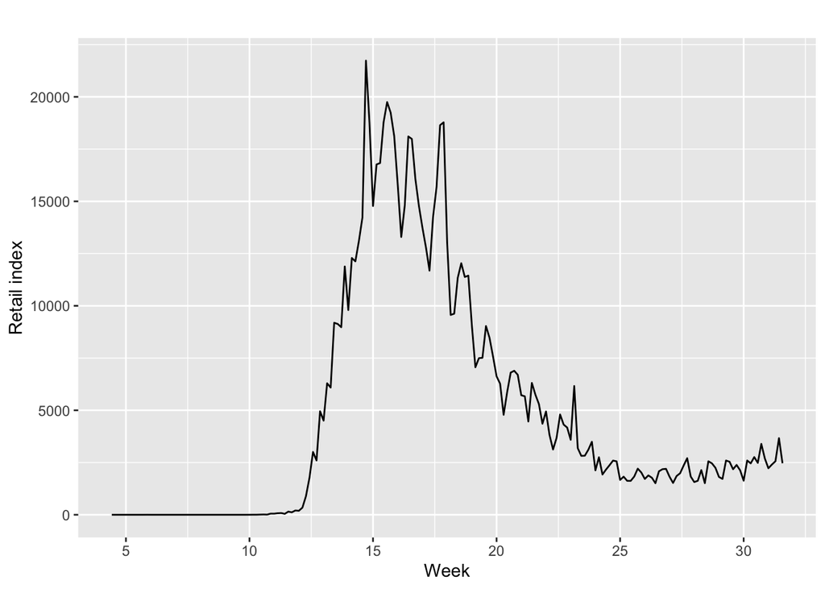

```r
autoplot(confirmed) + ylab("Retail index") + xlab("Week")
```

Thus, we first take a seasonal difference and the plot of resulting series, ACF and PACF are illustrated in the figure below. However, the series after a seasonal difference still does not seem to be stationary, so we take an additional first difference.

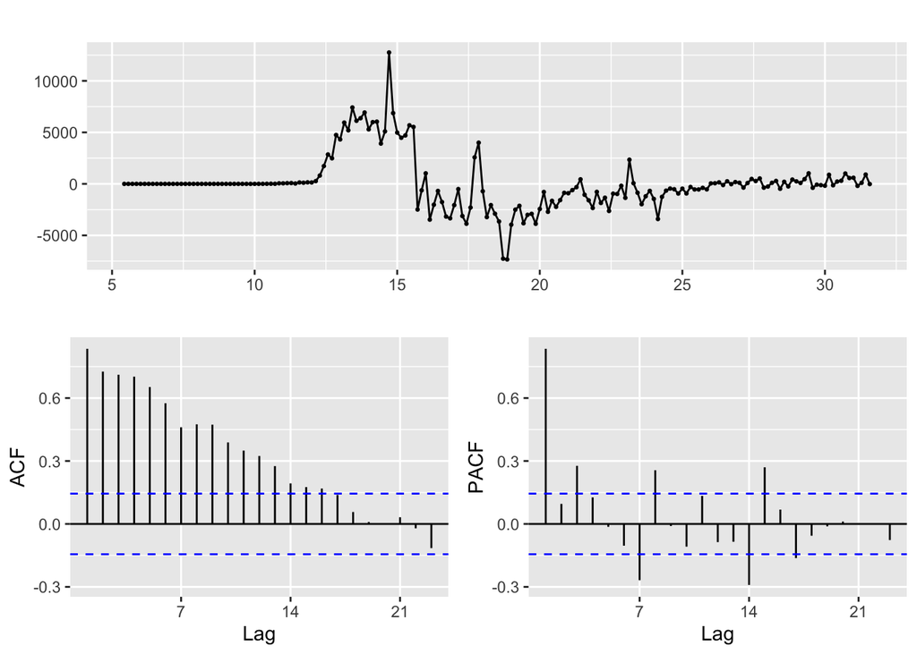

```r
confirmed %>% diff(lag=7) %>% ggtsdisplay()
```

The double differenced data seem to be stationary as indicated in the graph below. The significant spike at lag 2 in the ACF suggests a non-seasonal MA(2) component, and the significant spike at lag 7 in the ACF suggests a seasonal MA(1) component. Consequently, we begin with an $ARIMA(0,1,2)(0,1,1)_7$ model, indicating a first and seasonal difference, and non-seasonal MA(2) component and seasonal MA(1) components.

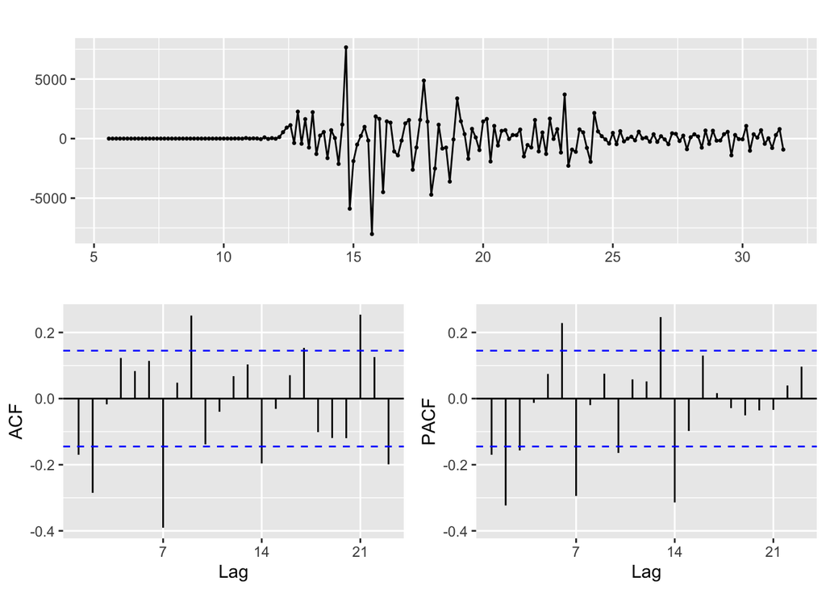

```r
confirmed %>% diff(lag=7) %>% diff() %>% ggtsdisplay()
```

# Seasonal ARIMA

## Model fitting

Now we fit $ARIMA(0,1,2)(0,1,1)_7$ model to the data and the residuals are plotted in the following figure. We see that there are spikes that exceed the significance limits, so the residuals do not appear to be white noise. The Ljung-Box test also shows that the residuals may have remaining autocorrelations. Thus, we need to modify the model further.

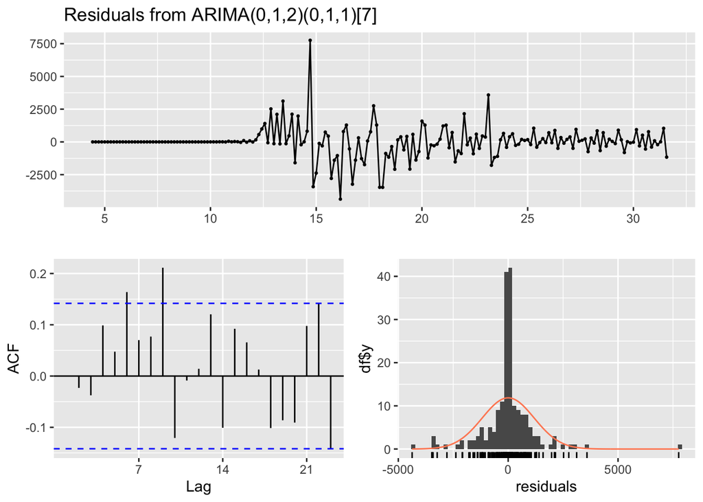

```
##
##  Ljung-Box test
##
## data:  Residuals from ARIMA(0,1,2)(0,1,1)[7]
## Q* = 27.463, df = 11, p-value = 0.00391
##
## Model df: 3.   Total lags used: 14
```

```r
fit1 <- Arima(confirmed, order=c(0,1,2), seasonal = c(0,1,1))
checkresiduals(fit1)
```

We run the `auto.arima` function to see which setup of the model gives the lowest AIC and BIC:

```r
auto.arima(confirmed, seasonal = TRUE)
```

```
## Series: confirmed
## ARIMA(2,1,2)(0,0,1)[7]
##
## Coefficients:
##          ar1      ar2      ma1     ma2    sma1
##       1.2500  -0.8975  -1.3709  0.8792  0.2177
## s.e.  0.0475   0.0484   0.0486  0.0546  0.0834
##
## sigma^2 = 1231663:  log likelihood = -1600.16
## AIC=3212.32   AICc=3212.78   BIC=3231.81
```

We see that model $ARIMA(2,1,2)(0,0,1)_7$ gives the lowest AIC and BIC. We can plot the residuals and conduct Ljung-Box test:

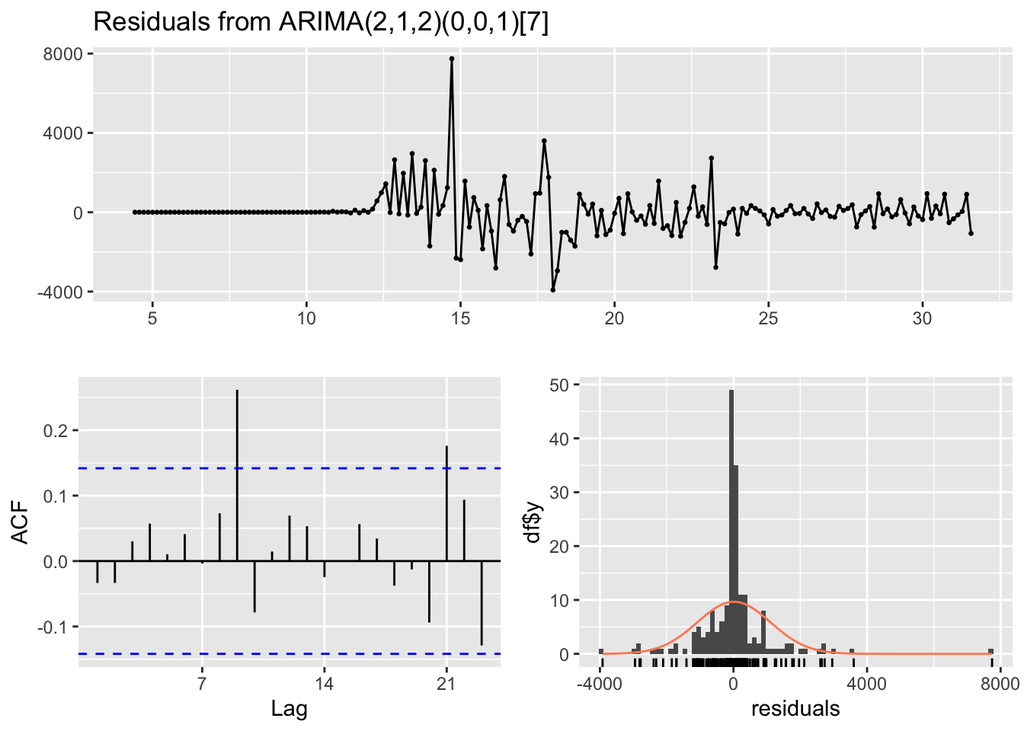

```
##
##  Ljung-Box test
##
## data:  Residuals from ARIMA(2,1,2)(0,0,1)[7]
## Q* = 19.569, df = 9, p-value = 0.02077
##
## Model df: 5.   Total lags used: 14
```

```r
fit2 <- Arima(confirmed, order=c(2,1,2), seasonal = c(0,0,1))
checkresiduals(fit2)
```

The result suggests that there is weak autocorrelation of residuals in our model.

## Forecasting

Load the test data:

```r
df_test <- read.csv("ne_test.csv", row.names = 1)
confirmed_test <- ts(df_test$confirmed, start = c(31,6), frequency = 7)
confirmed_test
```

```
## Time Series:
## Start = c(31, 6)
## End = c(38, 4)
## Frequency = 7
##  [1] 3056 2495 1949 1999 2093 3268 2228 2363 2365 1972 1875 2464 2668 2361 2267
## [16] 2135 1651 1501 1771 2253 1749 4398 2038 1475 2166 1893 2576 2279 2522 2339
## [31] 1855 2220 2453 2834 2973 2676 2514 2125 1729 1911 2654 2469 3085 2739 1446
## [46] 2925 2862 2845
```

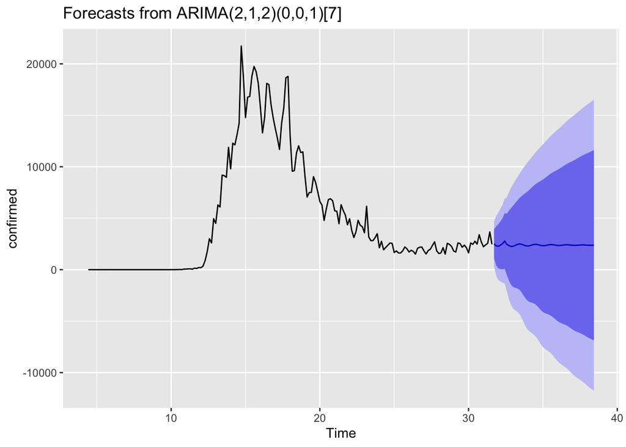

```r
fit2 %>% forecast(h=48) %>% autoplot()
```

Compute RMSE for test data:

```r
pred = data.frame(forecast(fit2, h=48))[,1]
# RMSE
sqrt(mean((pred-confirmed_test)^2))
```

```
## [1] 509.3609
```

## Model and forecasting for south

```r
df_south = read.csv("s_train.csv", row.names = 1)
df_south_test = read.csv("s_test.csv", row.names = 1)
confirmed_south <- ts(df_south$confirmed, start = c(4,4), frequency = 7)
auto.arima(confirmed_south, seasonal = TRUE)
```

```
## Series: confirmed_south
## ARIMA(0,1,1)(0,1,1)[7]
##
## Coefficients:
##           ma1     sma1
##       -0.4507  -0.6576
## s.e.   0.0605   0.0671
##
## sigma^2 = 1494794:  log likelihood = -1561.66
## AIC=3129.32   AICc=3129.45   BIC=3138.95
```

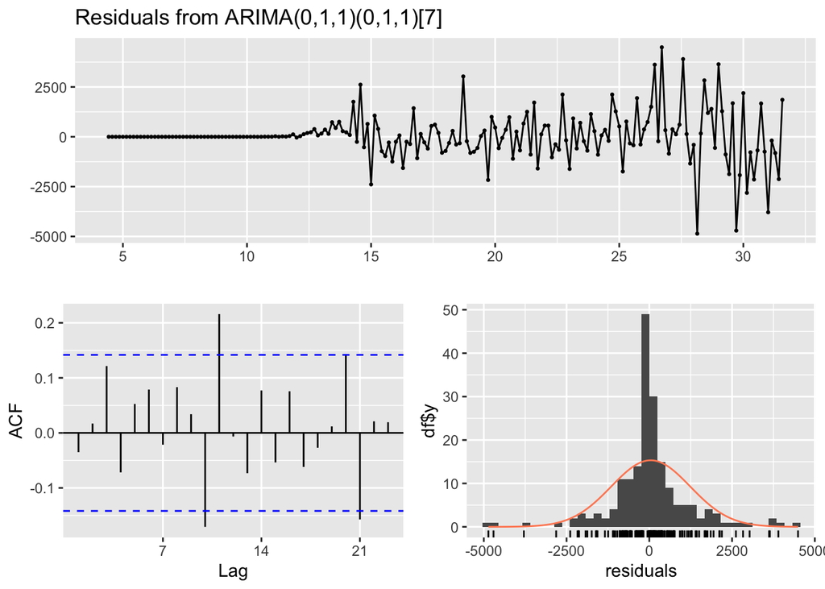

```
##
##  Ljung-Box test
##
## data:  Residuals from ARIMA(0,1,1)(0,1,1)[7]
## Q* = 25.542, df = 12, p-value = 0.01245
##
## Model df: 2.   Total lags used: 14
```

```r
fit_south <- Arima(confirmed_south, order=c(0,1,1), seasonal = c(0,1,1))
checkresiduals(fit_south)
```

```r
confirmed_south_test <- ts(df_south_test$confirmed, start = c(31,6), frequency = 7)
pred_south = data.frame(forecast(fit_south, h=48))[,1]
# RMSE
sqrt(mean((pred_south-confirmed_south_test)^2))
```

```
## [1] 17890.28
```

# Seasonal ARIMA with Log transformation

```r
log_confirmed <- log(confirmed+1)
auto.arima(log_confirmed, seasonal = TRUE)
```

```
## Series: log_confirmed
## ARIMA(2,2,2)
##
## Coefficients:
##           ar1      ar2     ma1      ma2
##       -1.2507  -0.4040  0.0727  -0.7765
## s.e.   0.0775   0.0712  0.0559   0.0533
##
## sigma^2 = 0.07429:  log likelihood = -21.63
## AIC=53.27   AICc=53.59   BIC=69.47
```

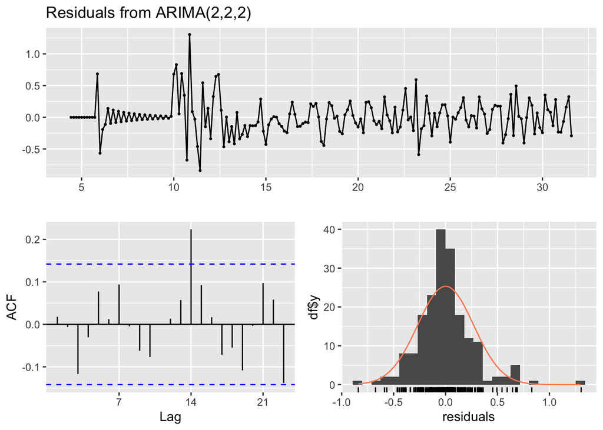

```
##
##  Ljung-Box test
##
## data:  Residuals from ARIMA(2,2,2)
## Q* = 19.017, df = 10, p-value = 0.04005
##
## Model df: 4.   Total lags used: 14
```

```r
fit3 <- arima(log_confirmed, order=c(2,2,2))
checkresiduals(fit3)
```

```r
# make predictions
pred3 = exp(data.frame(forecast(fit3, h=48))[,1])-1
# RMSE
sqrt(mean((pred3-confirmed_test)^2))
```

```
## [1] 1555.97
```

We see that the AIC and BIC after transformation is much smaller than the original model. However, this may be caused by the magnitude has been squeezed after transformation, and the prediction RMSE is even larger when we transform back to the original scale. Thus, the log transformation does not give a better prediction.

# ARIMA with exogenous variables (ARIMA-X)

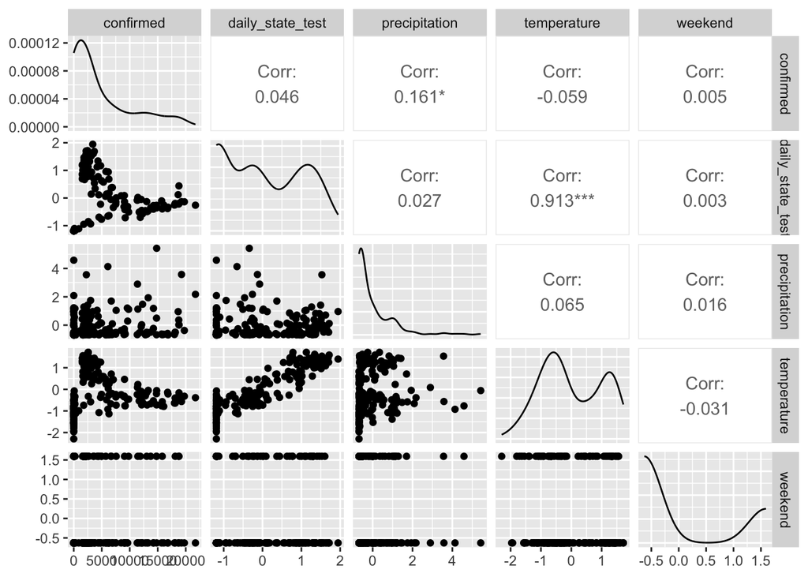

```r
df_sub <- df %>%
  select(confirmed, daily_state_test, precipitation, temperature, weekend)
df_sub %>% GGally::ggpairs()
```

# model fitting

```r
# Loading time series data and predictors
df_sub$confirmed <- ts(df_sub$confirmed, start = c(4,4), frequency = 7)
df_sub$daily_state_test <- ts(df_sub$daily_state_test, start = c(4,4), frequency = 7)
df_sub$precipitation <- ts(df_sub$precipitation, start = c(4,4), frequency = 7)
df_sub$temperature <- ts(df_sub$temperature, start = c(4,4), frequency = 7)
attach(df_sub)

# fit will all exogenous variables available
multi.fit1 <- auto.arima(confirmed, xreg = cbind(daily_state_test,precipitation,temperature, weekend))
summary(multi.fit1)
```

```
## Series: confirmed
## Regression with ARIMA(2,1,2)(0,0,1)[7] errors
##
## Coefficients:
##          ar1      ar2      ma1     ma2    sma1  daily_state_test  precipitation
##       1.2738  -0.9030  -1.4173  0.9248  0.1827          1582.627       -28.1466
## s.e.  0.0424   0.0429   0.0381  0.0451  0.0781           402.264        63.1072
##       temperature   weekend
##          134.8538  -50.3235
## s.e.     304.9366   93.9994
##
## sigma^2 = 1156724:  log likelihood = -1592.25
## AIC=3204.51   AICc=3205.74   BIC=3236.98
##
## Training set error measures:
##                    ME     RMSE      MAE MPE MAPE      MASE        ACF1
## Training set -11.6747 1046.978 576.1432 NaN  Inf 0.3849127 -0.07672849
```

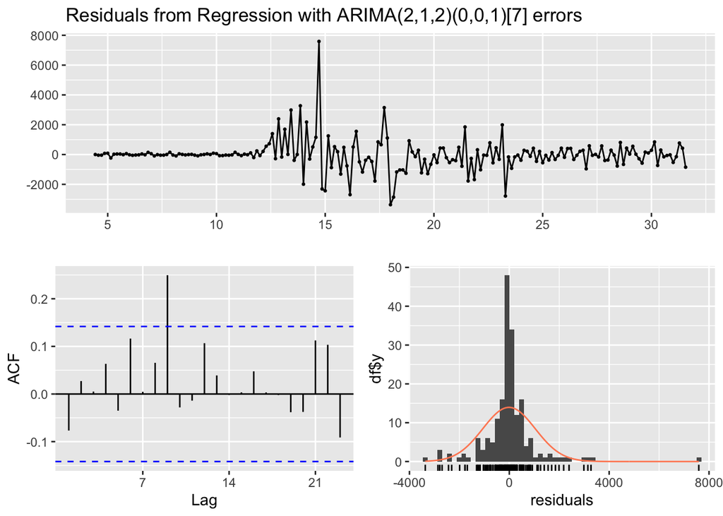

```
##
##  Ljung-Box test
##
## data:  Residuals from Regression with ARIMA(2,1,2)(0,0,1)[7] errors
## Q* = 21.369, df = 9, p-value = 0.01111
##
## Model df: 5.   Total lags used: 14
```

```r
checkresiduals(multi.fit1)
```

Thus, we search for other better fitting models by reducing exogenous variables:

```r
multi.fit2 <- auto.arima(confirmed, xreg = cbind(daily_state_test,precipitation,temperature))
multi.fit3 <- auto.arima(confirmed, xreg = cbind(precipitation,temperature))
multi.fit4 <- auto.arima(confirmed, xreg = cbind(daily_state_test,precipitation))
multi.fit5 <- auto.arima(confirmed, xreg = cbind(precipitation))
data.frame(
  model = c("multi.fit1", "multi.fit2", "multi.fit3", "multi.fit4", "multi.fit5"),
  AIC = c(multi.fit1$aic, multi.fit2$aic, multi.fit3$aic, multi.fit4$aic, multi.fit5$aic),
  BIC = c(multi.fit1$bic, multi.fit2$bic, multi.fit3$bic, multi.fit4$bic, multi.fit5$bic))
```

```
##        model      AIC      BIC
## 1 multi.fit1 3204.506 3236.977
## 2 multi.fit2 3202.792 3232.015
## 3 multi.fit3 3216.054 3242.030
## 4 multi.fit4 3201.023 3226.999
## 5 multi.fit5 3214.076 3236.805
```

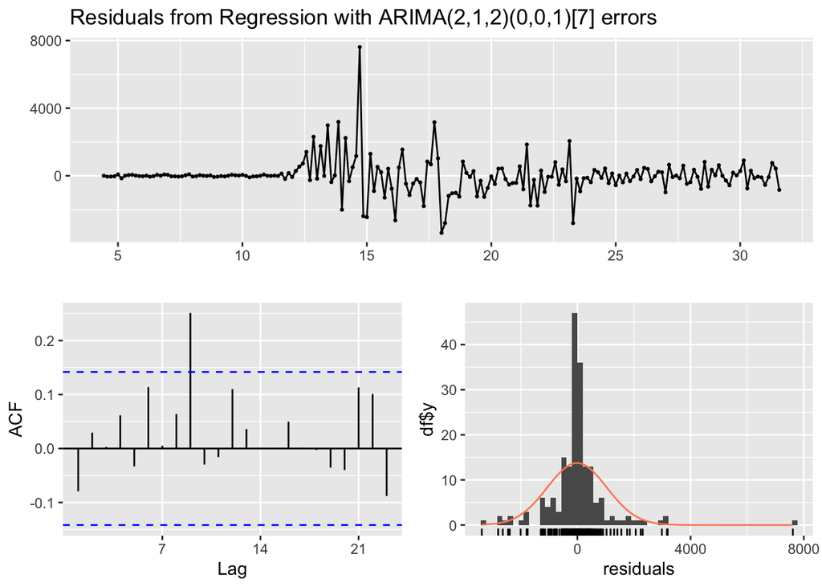

```
##
##  Ljung-Box test
##
## data:  Residuals from Regression with ARIMA(2,1,2)(0,0,1)[7] errors
## Q* = 21.508, df = 9, p-value = 0.01058
##
## Model df: 5.   Total lags used: 14
```

```
## [1] 0.01057669
```

```r
checkresiduals(multi.fit2)$p.value
```

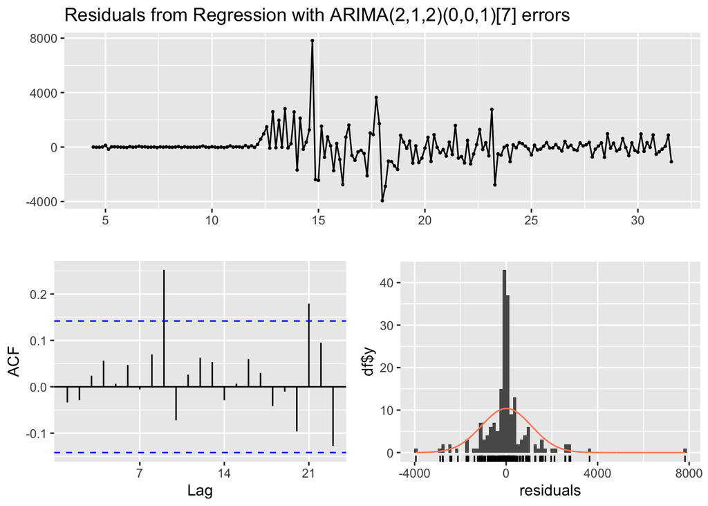

```
##
##  Ljung-Box test
##
## data:  Residuals from Regression with ARIMA(2,1,2)(0,0,1)[7] errors
## Q* = 18.202, df = 9, p-value = 0.0329
##
## Model df: 5.   Total lags used: 14
```

```
## [1] 0.03289677
```

```r
checkresiduals(multi.fit3)$p.value
```

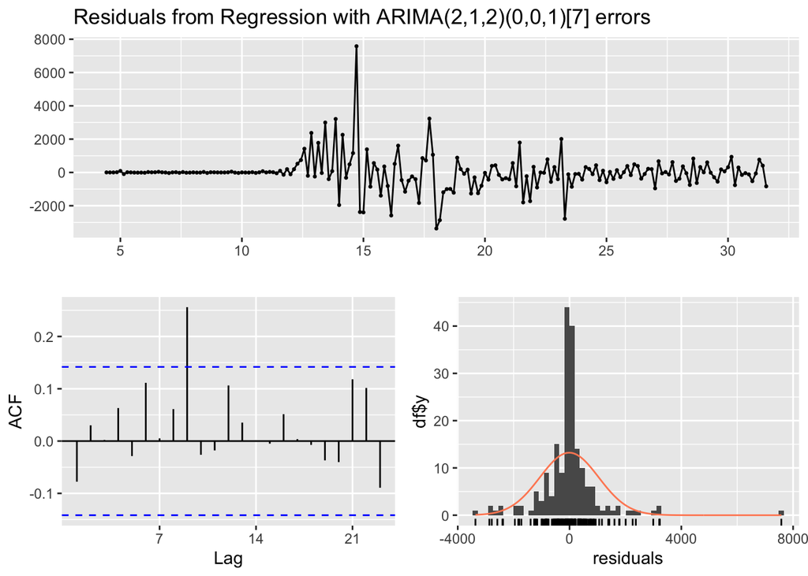

```
##
##  Ljung-Box test
##
## data:  Residuals from Regression with ARIMA(2,1,2)(0,0,1)[7] errors
## Q* = 21.595, df = 9, p-value = 0.01026
##
## Model df: 5.   Total lags used: 14
```

```
## [1] 0.01025617
```

```r
checkresiduals(multi.fit4)$p.value
```

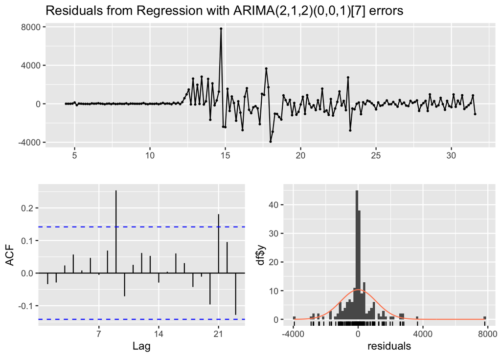

```
##
##  Ljung-Box test
##
## data:  Residuals from Regression with ARIMA(2,1,2)(0,0,1)[7] errors
## Q* = 18.292, df = 9, p-value = 0.03193
##
## Model df: 5.   Total lags used: 14
```

```
## [1] 0.03193275
```

```r
checkresiduals(multi.fit5)$p.value
```

Below is a plot of true value and fitted values:

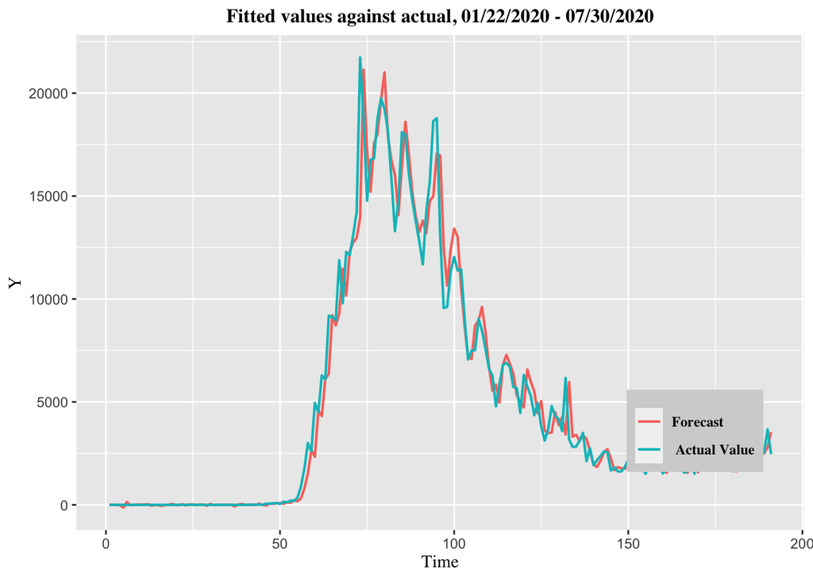

```r
fitted_confirmed <- fitted(multi.fit5)
confirmed_df = data.frame(
  time = 1:length(confirmed),
  value = c(confirmed, fitted_confirmed),
  type = c(rep("true", length(confirmed)), rep("forecasts", length(fitted_confirmed)))
)
ggplot(confirmed_df, aes(x = time, y = value, col = as.factor(type))) +
  geom_line(size = 0.75) +
  labs(y = "Y", x ="Time",
  title = "Fitted values against actual, 01/22/2020 - 07/30/2020") +
  theme(axis.title = element_text(family = "serif"),
        plot.title = element_text(hjust = 0.5, size = 12, family = "serif", face = "bold"),
        legend.position = c(0.85, 0.2),
        legend.title = element_blank(),
        legend.text = element_text(family = "serif", face = "bold"),
        legend.key = element_rect(color = "transparent"),
        legend.background = element_rect(fill = "lightgrey")) +
  scale_color_discrete(name = "Lead", labels = c("Forecast"," Actual Value"))
```

We see that the model fits well.

## Forecasting

```r
pred.fit5 = data.frame(forecast(multi.fit5, xreg = df_test$precipitation))[,1]
# RMSE
sqrt(mean((pred.fit5-confirmed_test)^2))
```

```
## [1] 510.8163
```

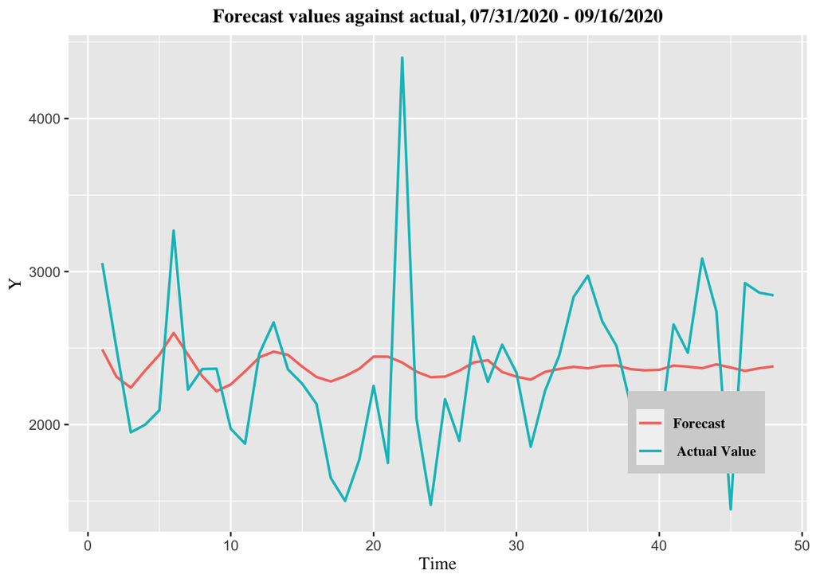

```r
pred_df = data.frame(
  time = 1:length(df_test$confirmed),
  value = c(df_test$confirmed, pred.fit5),
  type = c(rep("true", length(df_test$confirmed)), rep("forecasts", length(pred.fit5)))
)
ggplot(pred_df, aes(x = time, y = value, col = as.factor(type))) +
  geom_line(size = 0.75) +
  labs(y = "Y", x ="Time",
  title = "Forecast values against actual, 07/31/2020 - 09/16/2020") +
  theme(axis.title = element_text(family = "serif"),
        plot.title = element_text(hjust = 0.5, size = 12, family = "serif", face = "bold"),
        legend.position = c(0.85, 0.2),
        legend.title = element_blank(),
        legend.text = element_text(family = "serif", face = "bold"),
        legend.key = element_rect(color = "transparent"),
        legend.background = element_rect(fill = "lightgrey")) +
  scale_color_discrete(name = "Lead", labels = c("Forecast"," Actual Value"))
```